# Math 420 HW 1

Fall 2024

Washington University in St. Louis

Due date: Sunday, 9/15/2024

## Instruction:

Please type your answers clearly and show your work neatly. You are encouraged to use the Rmarkdown version of this assignment as a template to submit your work. Unless stated otherwise, all programming references in the assignment will be in R. For this assignment, problems roughly covers content from Complete Random Design and Factorial Designs

## Problem 1

#### Describe a situation within your realm of experience (your work, your hobby, or school) where you might like to predict result of some future action. Explain how experimental design, rather than observational study, might enhance your ability to make this prediction.

.

Answer:

Situation: I really like swimming when I have leisure time, and I want to know which swimming stroke is the fastest,for example, freestyle, breaststroke or backstroke?

Design:

1.Controllable factors:Every Saturday at 1pm, the same swimming pool, the same dress code, the same swimming distance.

2.Choose the type of swimming strokes randomly.

3.Record the time taken for each swim.

4.Analyze the results:Compare the times to see which stroke is the fastest.

The advantages of the experimental design than observational study.

1. The results are more visual. It is much easy to compare the data than relying on visual judgment.

2.The cause-and-effect relationships is much stronger than observational study for the reason that there are less confounding factors.

3.There is more control over confounding variables by planning experiment.

## Problem 2

#### Paper helicopters can be cut from one half of an 812 ×11 sheet of paper as shown below.

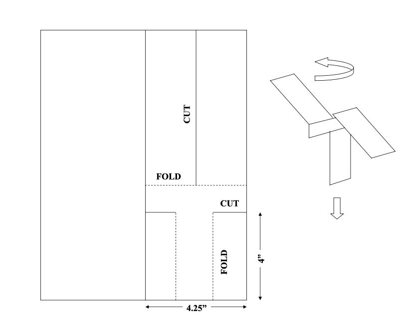

Figure 1

#### These helicopters can be made quickly and inexpensively, and can be used to demonstrate experimental design concepts. An experiment can be per- formed by constructing a helicopter, dropping it from a fixed height, and clocking the time it takes to rotate to the floor, as shown above, with a stopwatch. The wing length could be varied by trimming some paper off the top prior to folding the wings. Trimming some paper off would reduce the weight of the helicopter, but would also result in less surface area on the blades. You could experiment to determine if changing the wing length affects the flight time.

1. Describe the experimental unit.

   The experimental unit:Paper helicopters
2. Explain the difference in replicates and duplicates for this situation.

   Replicates:Replicate means that repeat experiments multiple times under the same experimental conditions.For example,for this situation, we can keep the wing length unchanged, and just repeat to drop the helicopters many times from a fixed height to acquire different data.

   Duplicates:Duplicates means that keep the experimental conditions unchanged, but change the experiment unit.For example,in this situation, use a same wing length in different paper helicopters.
3. Describe the treatment factor.

   The treatment factor:the wing length.
4. Describe any lurking variables that might affect the results of experiments.

   1.If it is an outdoor experiment, then the speed of wind, the weather conditions and even the moisture may affect the results.

   2.The quality of the paper.
5. Explain why randomization would be important.

   1.Randomization can reduce the effects of some noises which are difficult to control when doing the experiment.

   2.It can make the results of the experiment more common.